# Sociodemographic Determinants of COVID-19 Vaccine Uptake in Ontario

Independent Analysis Part 1B — Data Wrangling and Descriptive Statistics

Maureen Amuche Nwobodo

2026-04-21

# 1 INTRODUCTION

This report presents the first stage of analysis for the Ontario vaccination dataset. The focus is on importing the data, cleaning and preparing it for analysis, and producing descriptive statistics and visualizations that summarize the key features of the dataset.

# 2 LOAD PACKAGES

```r
library(tidyverse)
library(readxl)
library(janitor)
library(lubridate)
library(scales)
library(skimr)
library(knitr)
library(kableExtra)
library(lubridate)
library(forcats)
```

# 3 LOAD DATA

```r
vaccine_data <- read_excel("C:/Users/bds268/OneDrive - University of Saskatchewan/Desktop/USL_PCA_files/Ontario Vaccination Status.xlsx") |>
  clean_names()
```

# 4 EXAMINE DATA STRUCTURE

```r
glimpse(vaccine_data)
```

```
## Rows: 720,720
## Columns: 7
## $ public_health_unit               <chr> "Algoma Public Health", "Algoma Publi…
## $ gender                           <chr> "Female", "Female", "Female", "Female…
## $ age_group                        <chr> "0 to 4", "0 to 4", "0 to 4", "0 to 4…
## $ vaccination_status               <chr> "At least one dose", "At least one do…
## $ week_start_date                  <dttm> 2020-12-13, 2020-12-20, 2020-12-27, …
## $ number_of_individuals_vaccinated <dbl> 0, 0, 0, 0, 0, 0, 0, 0, 0, 0, 0, 0, 0…
## $ population                       <dbl> 2214, 2214, 2214, 2214, 2214, 2214, 2…
```

```r
summary(vaccine_data)
```

```
##  public_health_unit    gender           age_group         vaccination_status
##  Length:720720      Length:720720      Length:720720      Length:720720
##  Class :character   Class :character   Class :character   Class :character
##  Mode  :character   Mode  :character   Mode  :character   Mode  :character
##
##
##
##
##  week_start_date               number_of_individuals_vaccinated
##  Min.   :2020-12-13 00:00:00   Min.   :    0.00
##  1st Qu.:2021-09-10 06:00:00   1st Qu.:    0.00
##  Median :2022-06-08 12:00:00   Median :    0.00
##  Mean   :2022-06-08 12:00:00   Mean   :   50.49
##  3rd Qu.:2023-03-06 18:00:00   3rd Qu.:    2.00
##  Max.   :2023-12-03 00:00:00   Max.   :41687.00
##
##    population
##  Min.   :   810
##  1st Qu.:  5968
##  Median : 10776
##  Mean   : 22597
##  3rd Qu.: 25295
##  Max.   :293565
##  NA's   :296400
```

- The four main predictor variables are all stored as text (character) and therefore do not show frequencies in summary(), The dataset covers almost three years of weekly data. The median and mean of the `week_start_date` are almost identical which suggests roughly balanced coverage over time. The `number_of_individuals_vaccinated` is strongly right-skew with a `Mean (50.49) >> median (0)` which indicates massive inequality in vaccination counts across strata. The dataset has very uneven population sizes with some strata as small as (≈800 people) and others are as large as (≈300,000 people). Also, population variables has large number of missing values ~41% of population values are missing (296,400 / 720,720 ≈ 41%).

The table below documents the seven variables.

Variable dictionary

| Variable | Type | Description |
| --- | --- | --- |
| public_health_unit | categorical | One of 34 PHUs + ‘Unknown’ |
| gender | categorical | Female / Male / Unknown |
| age_group | ordinal | 0 to 4 … 80+ / Missing (11 levels) |
| vaccination_status | categorical | At least one dose / primary series / +1 booster / +2 boosters |
| week_start_date | date | Epidemiological week start (weekly from 2020-12-13) |
| number_of_individuals_vaccinated | count | Count of individuals with that vaccination status (weighting variable) |
| population | count | 2023 PHU-gender-age population denominator |

# 5 MISSING DATA ASSESEMENT

```r
missing_summary <- sapply(vaccine_data, function(x) sum(is.na(x)))
missing_summary
```

```
##               public_health_unit                           gender
##                                0                                0
##                        age_group               vaccination_status
##                                0                                0
##                  week_start_date number_of_individuals_vaccinated
##                                0                                0
##                       population
##                           296400
```

```r
round(colMeans(is.na(vaccine_data)) * 100, 2)
```

```
##               public_health_unit                           gender
##                             0.00                             0.00
##                        age_group               vaccination_status
##                             0.00                             0.00
##                  week_start_date number_of_individuals_vaccinated
##                             0.00                             0.00
##                       population
##                            41.13
```

- The missingness assessment here shows that only the variable `population` has missing values which is proportional to about 41.13% of the whole observation, but it did not reflect the “Unknown” values which we observed in the table above for the `age`, `public health units` and `gender` variables.

# 6 DATA WRANGLING

## 6.1 Convert Data Types

```r
data <- vaccine_data |>
  mutate(
    public_health_unit = as.factor(public_health_unit),
    gender = as.factor(gender),
    age_group = factor(
      age_group,
      levels = c("0 to 4", "5 to 11", "12 to 17", "18 to 29", "30 to 39",
                 "40 to 49", "50 to 59", "60 to 69", "70 to 79", "80+", "Missing"),
      ordered = TRUE
    ),
    vaccination_status = factor(
      vaccination_status,
      levels = c(
        "At least one dose",
        "Completed primary series",
        "Completed primary series and 1 booster dose",
        "Completed primary series and 2+ booster doses"
      )
    ),
    week_start_date = as.Date(week_start_date)
  )
```

## 6.2 Create Derived Variables

```r
data <- data |>
  mutate(
    vaccination_coverage = ifelse(
      !is.na(population) & population > 0,
      number_of_individuals_vaccinated / population,
      NA_real_
    ),
    year = year(week_start_date),
    month = month(week_start_date, label = TRUE, abbr = TRUE)
  )
```

## 6.3 Check Cleaned Structure

```r
glimpse(data)
```

```
## Rows: 720,720
## Columns: 10
## $ public_health_unit               <fct> "Algoma Public Health", "Algoma Publi…
## $ gender                           <fct> Female, Female, Female, Female, Femal…
## $ age_group                        <ord> 0 to 4, 0 to 4, 0 to 4, 0 to 4, 0 to …
## $ vaccination_status               <fct> At least one dose, At least one dose,…
## $ week_start_date                  <date> 2020-12-13, 2020-12-20, 2020-12-27, …
## $ number_of_individuals_vaccinated <dbl> 0, 0, 0, 0, 0, 0, 0, 0, 0, 0, 0, 0, 0…
## $ population                       <dbl> 2214, 2214, 2214, 2214, 2214, 2214, 2…
## $ vaccination_coverage             <dbl> 0, 0, 0, 0, 0, 0, 0, 0, 0, 0, 0, 0, 0…
## $ year                             <dbl> 2020, 2020, 2020, 2021, 2021, 2021, 2…
## $ month                            <ord> Dec, Dec, Dec, Jan, Jan, Jan, Jan, Ja…
```

# 7 DESCRIPTIVE STATISTICS

## 7.1 Frequencies for Categorical Variables

```r
table(data$gender)
```

```
##
##  Female    Male Unknown
##  240240  240240  240240
```

```r
table(data$age_group, useNA = "ifany")
```

```
##
##   0 to 4  5 to 11 12 to 17 18 to 29 30 to 39 40 to 49 50 to 59 60 to 69
##    65520    65520    65520    65520    65520    65520    65520    65520
## 70 to 79      80+  Missing
##    65520    65520    65520
```

```r
table(data$vaccination_status)
```

```
##
##                             At least one dose
##                                        180180
##                      Completed primary series
##                                        180180
##   Completed primary series and 1 booster dose
##                                        180180
## Completed primary series and 2+ booster doses
##                                        180180
```

- The dataset contains an equal number of stratified records for each gender, age group, and vaccination status. Counts represent reporting strata rather than individuals since the dataset is aggregated.

## 7.2 Summary of Numeric Variables

```r
data |>
  select(number_of_individuals_vaccinated, population, vaccination_coverage) |>
  summary()
```

```
##  number_of_individuals_vaccinated   population     vaccination_coverage
##  Min.   :    0.00                 Min.   :   810   Min.   :0.000
##  1st Qu.:    0.00                 1st Qu.:  5968   1st Qu.:0.000
##  Median :    0.00                 Median : 10776   Median :0.000
##  Mean   :   50.49                 Mean   : 22597   Mean   :0.003
##  3rd Qu.:    2.00                 3rd Qu.: 25295   3rd Qu.:0.001
##  Max.   :41687.00                 Max.   :293565   Max.   :0.524
##                                   NA's   :296400   NA's   :296400
```

## 7.3 Quick Data Overview

```r
skimr::skim(data)
```

Data summary

| Name | data |
| --- | --- |
| Number of rows | 720720 |
| Number of columns | 10 |
| _______________________ |  |
| Column type frequency: |  |
| Date | 1 |
| factor | 5 |
| numeric | 4 |
| ________________________ |  |
| Group variables | None |

**Variable type: Date**

| skim_variable | n_missing | complete_rate | min | max | median | n_unique |
| --- | --- | --- | --- | --- | --- | --- |
| week_start_date | 0 | 1 | 2020-12-13 | 2023-12-03 | 2022-06-08 | 156 |

**Variable type: factor**

| skim_variable | n_missing | complete_rate | ordered | n_unique | top_counts |
| --- | --- | --- | --- | --- | --- |
| public_health_unit | 0 | 1 | FALSE | 35 | Alg: 20592, Bra: 20592, Cha: 20592, Cit: 20592 |
| gender | 0 | 1 | FALSE | 3 | Fem: 240240, Mal: 240240, Unk: 240240 |
| age_group | 0 | 1 | TRUE | 11 | 0 t: 65520, 5 t: 65520, 12 : 65520, 18 : 65520 |
| vaccination_status | 0 | 1 | FALSE | 4 | At : 180180, Com: 180180, Com: 180180, Com: 180180 |
| month | 0 | 1 | TRUE | 12 | Jan: 69300, Oct: 69300, May: 64680, Jul: 64680 |

**Variable type: numeric**

| skim_variable | n_missing | complete_rate | mean | sd | p0 | p25 | p50 | p75 | p100 | hist |
| --- | --- | --- | --- | --- | --- | --- | --- | --- | --- | --- |
| number_of_individuals_vaccinated | 0 | 1.00 | 50.49 | 477.57 | 0 | 0.00 | 0 | 2 | 41687.00 | ▇▁▁▁▁ |
| population | 296400 | 0.59 | 22596.82 | 34312.43 | 810 | 5967.75 | 10776 | 25295 | 293565.00 | ▇▁▁▁▁ |
| vaccination_coverage | 296400 | 0.59 | 0.00 | 0.02 | 0 | 0.00 | 0 | 0 | 0.52 | ▇▁▁▁▁ |
| year | 0 | 1.00 | 2021.94 | 0.85 | 2020 | 2021.00 | 2022 | 2023 | 2023.00 | ▁▇▁▇▇ |

## 7.4 Grouped Descriptive Statistics

### 7.4.1 Total Vaccinated Individuals by Vaccination Status

```r
data |>
  group_by(vaccination_status) |>
  summarise(
    total_vaccinated = sum(number_of_individuals_vaccinated, na.rm = TRUE),
    .groups = "drop"
  )
```

| vaccination_status | total_vaccinated |
| --- | --- |
| At least one dose | 12659684 |
| Completed primary series | 12210505 |
| Completed primary series and 1 booster dose | 7733305 |
| Completed primary series and 2+ booster doses | 3783997 |

- Cumulatively, approximately 12.7 million individuals received at least one COVID‑19 vaccine dose during the study period, with nearly all completing the primary series. Booster uptake was lower, with about 7.7 million individuals receiving at least one booster dose and approximately 3.8 million receiving two or more boosters, indicating progressive decline in vaccination uptake with increasing dose number.

### 7.4.2 Total Vaccinated Individuals by Gender

```r
data |>
  group_by(gender) |>
  summarise(
    total_vaccinated = sum(number_of_individuals_vaccinated, na.rm = TRUE),
    .groups = "drop"
  )
```

| gender | total_vaccinated |
| --- | --- |
| Female | 18927014 |
| Male | 17387198 |
| Unknown | 73279 |

- In aggregate, a greater number of vaccinations were administered to females (18.9 million) than to males (17.4 million) over the study period, while vaccinations with unknown gender accounted for a negligible proportion of records. This table above reflect cumulative vaccination counts rather than unique individuals.

### 7.4.3 Total Vaccinated Individuals by Age Group

```r
data |>
  group_by(age_group) |>
  summarise(
    total_vaccinated = sum(number_of_individuals_vaccinated, na.rm = TRUE),
    .groups = "drop"
  )
```

| age_group | total_vaccinated |
| --- | --- |
| 0 to 4 | 99109 |
| 5 to 11 | 963639 |
| 12 to 17 | 1741033 |
| 18 to 29 | 5471746 |
| 30 to 39 | 5118188 |
| 40 to 49 | 4801604 |
| 50 to 59 | 5371953 |
| 60 to 69 | 5963666 |
| 70 to 79 | 4339259 |
| 80+ | 2508975 |

[output cut: 1 more lines]

- Vaccination counts varied substantially by age group, with the highest cumulative numbers observed among adults aged 18–69 years, particularly those aged 60–69. Lower totals among children and adolescents likely reflect later eligibility and smaller vaccination volumes, while reduced counts in the oldest age groups are consistent with smaller population sizes rather than lower coverage.

### 7.4.4 Average Vaccination Coverage by Vaccination Status

```r
data |>
  group_by(vaccination_status) |>
  summarise(
    mean_coverage = mean(vaccination_coverage, na.rm = TRUE),
    median_coverage = median(vaccination_coverage, na.rm = TRUE),
    .groups = "drop"
  )
```

| vaccination_status | mean_coverage | median_coverage |
| --- | --- | --- |
| At least one dose | 0.004769370 | 9.753719e-05 |
| Completed primary series | 0.004582786 | 9.782821e-05 |
| Completed primary series and 1 booster dose | 0.002967208 | 2.347363e-05 |
| Completed primary series and 2+ booster doses | 0.001651400 | 0.000000e+00 |

# 8 VISUALIZATIONS

## 8.1 Distribution of Vaccination Status

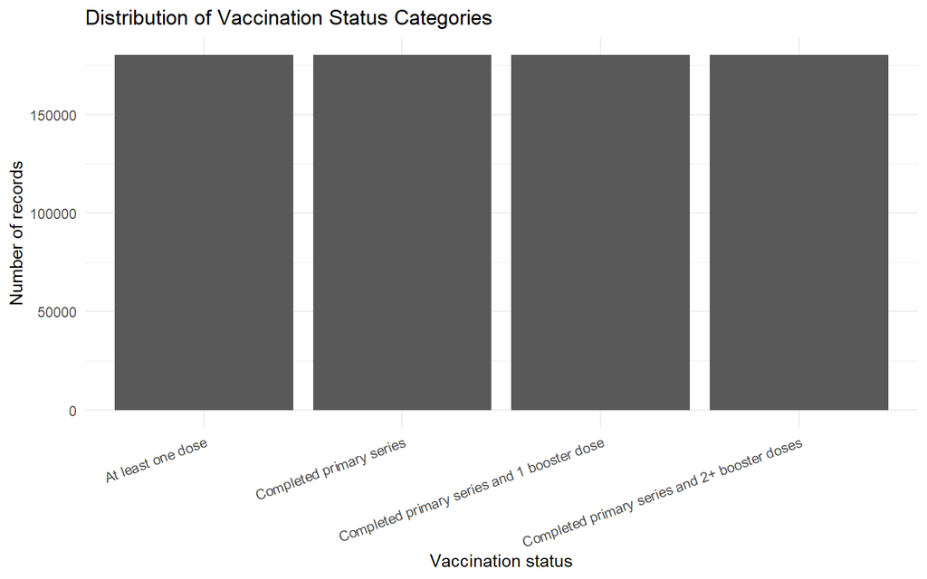

```r
ggplot(data, aes(x = vaccination_status)) +
  geom_bar() +
  labs(
    title = "Distribution of Vaccination Status Categories",
    x = "Vaccination status",
    y = "Number of records"
  ) +
  theme_minimal() +
  theme(axis.text.x = element_text(angle = 20, hjust = 1))
```

- The distribution of records across vaccination status categories is uniform, reflecting the stratified structure of the dataset rather than differences in vaccination uptake. Each vaccination status category is represented by a similar number of reporting records across demographic groups and time periods.

## 8.2 Total Vaccinated Individuals by Gender

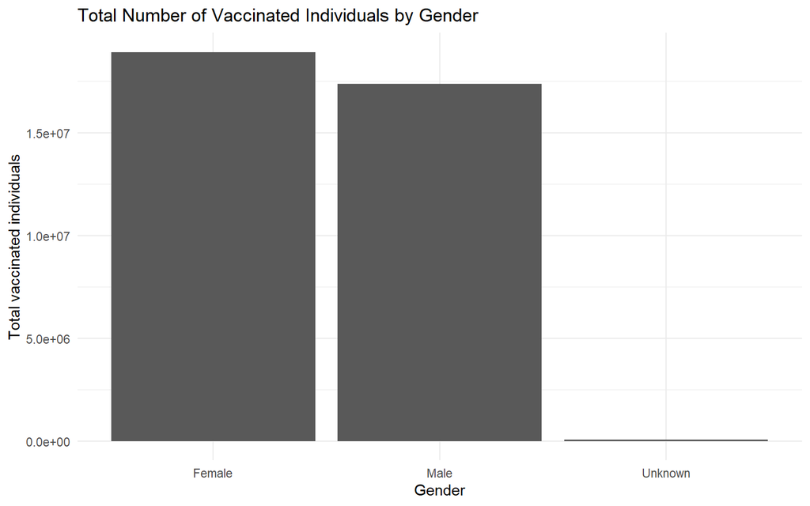

```r
data |>
  group_by(gender) |>
  summarise(total_vaccinated = sum(number_of_individuals_vaccinated, na.rm = TRUE)) |>
  ggplot(aes(x = gender, y = total_vaccinated)) +
  geom_col() +
  labs(
    title = "Total Number of Vaccinated Individuals by Gender",
    x = "Gender",
    y = "Total vaccinated individuals"
  ) +
  theme_minimal()
```

- The total number of recorded vaccinations was slightly higher among females than males over the study period, while vaccinations with unknown gender accounted for a negligible proportion. These counts represent cumulative vaccination events rather than unique individuals and therefore reflect overall vaccination volume rather than coverage.

## 8.3 Total Vaccinated Individuals by Age Group

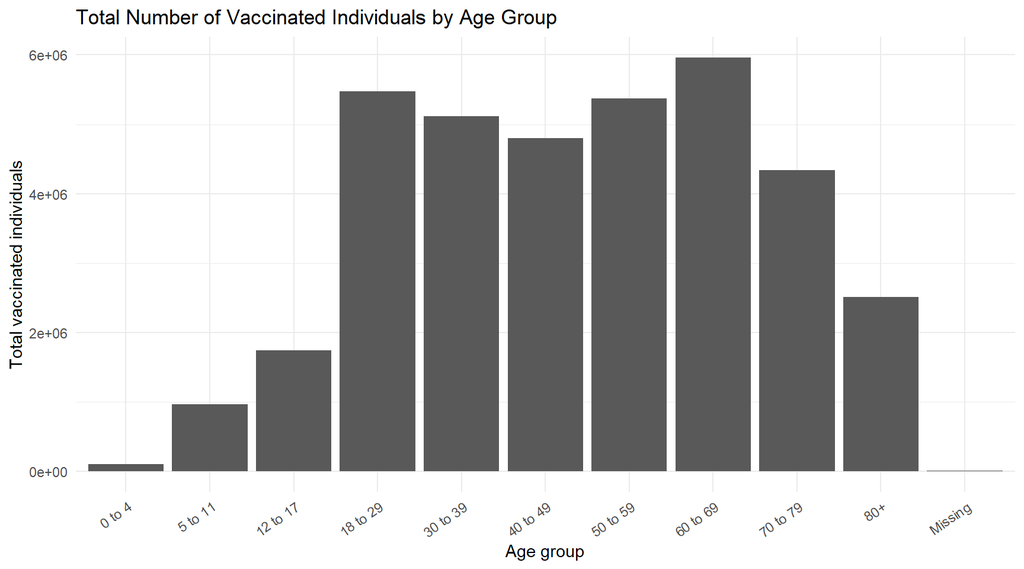

```r
data |>
  group_by(age_group) |>
  summarise(total_vaccinated = sum(number_of_individuals_vaccinated, na.rm = TRUE)) |>
  ggplot(aes(x = age_group, y = total_vaccinated)) +
  geom_col() +
  labs(
    title = "Total Number of Vaccinated Individuals by Age Group",
    x = "Age group",
    y = "Total vaccinated individuals"
  ) +
  theme_minimal() +
  theme(axis.text.x = element_text(angle = 35, hjust = 1))
```

- Vaccination counts varied substantially by age group, with the highest cumulative totals observed among adults aged 18–69 years, particularly those aged 60–69. Lower totals among children reflect later eligibility and lower vaccination volumes, while declines in the oldest age groups are consistent with smaller population sizes rather than reduced uptake.

## 8.4 Weekly Trend in Number of Vaccinated Individuals

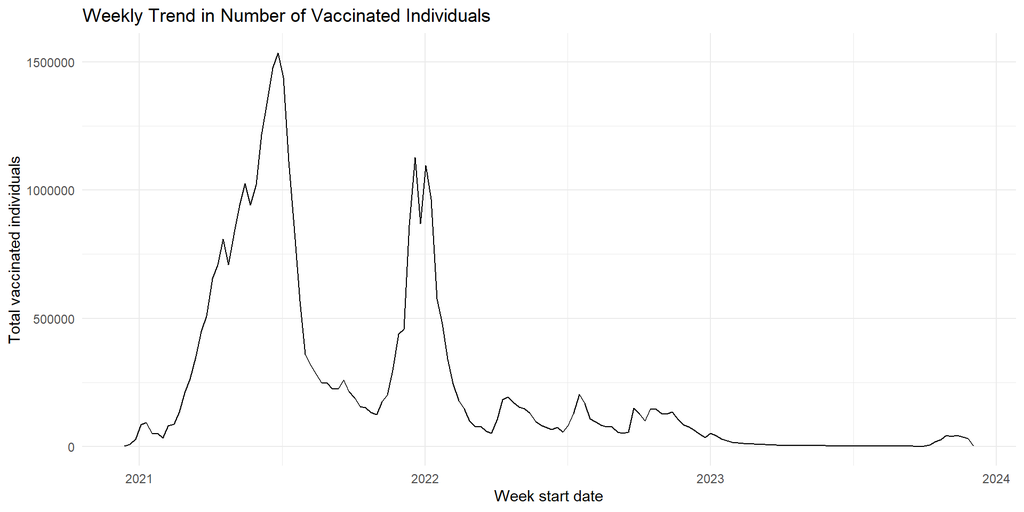

```r
data |>
  group_by(week_start_date) |>
  summarise(total_vaccinated = sum(number_of_individuals_vaccinated, na.rm = TRUE)) |>
  ggplot(aes(x = week_start_date, y = total_vaccinated)) +
  geom_line() +
  labs(
    title = "Weekly Trend in Number of Vaccinated Individuals",
    x = "Week start date",
    y = "Total vaccinated individuals"
  ) +
  theme_minimal()
```

- Weekly vaccination activity increased rapidly during early 2021, reaching a peak in mid‑2021 corresponding to the initial mass vaccine rollout. This was followed by a sharp decline as primary vaccination coverage was achieved. A secondary peak in early 2022 reflects booster dose administration, after which weekly vaccination numbers gradually decreased to low levels by 2023, indicating a transition to targeted vaccination efforts.

# 9 Drop Categorical Placeholders for Missing Values

```r
clean <- data |>
  filter(
    gender             != "Unknown",
    age_group          != "Missing",
    public_health_unit != "Unknown",
    !is.na(population),
    population > 0
  )

# Rows dropped
tibble(
  stage     = c("data", "After dropping Unknown / Missing / NA pop"),
  rows      = c(nrow(data), nrow(clean)),
  dropped   = c(NA_integer_, nrow(data) - nrow(clean))
) |>
  kable(booktabs = TRUE, caption = "Row counts before and after missing-value handling")
```

Row counts before and after missing-value handling

| stage | rows | dropped |
| --- | --- | --- |
| data | 720720 | NA |
| After dropping Unknown / Missing / NA pop | 424320 | 296400 |

- The original dataset contained 720,720 stratified records. After excluding observations with missing or undefined population values, 424,320 records (58.9%) remained for analysis, with 296,400 records (41.1%) removed. This cleaning step was necessary to ensure valid population‑based rate calculations but reduced overall coverage of reporting strata.

# 10 Factor Levels with the Correct Reference Categories

```r
age_order <- c("0 to 4", "5 to 11", "12 to 17", "18 to 29",
               "30 to 39", "40 to 49", "50 to 59", "60 to 69",
               "70 to 79", "80+")

clean <- clean |>
  mutate(
    gender             = factor(gender, levels = c("Male", "Female")),
    age_group          = factor(age_group, levels = age_order),
    public_health_unit = fct_relevel(factor(public_health_unit),
                                     "Toronto Public Health"),
    vaccination_status = factor(vaccination_status),
    week_start_date    = as.Date(week_start_date)
  )

levels(clean$gender)
```

```
## [1] "Male"   "Female"
```

```r
head(levels(clean$age_group), 3)
```

```
## [1] "0 to 4"   "5 to 11"  "12 to 17"
```

```r
head(levels(clean$public_health_unit), 3)
```

```
## [1] "Toronto Public Health"    "Algoma Public Health"
## [3] "Brant County Health Unit"
```

- Categorical variables were explicitly converted to factors with predefined reference levels to ensure meaningful statistical interpretation. Age groups were ordered chronologically, male gender and Toronto Public Health were selected as reference categories, and vaccination status was treated as a categorical variable. Week start dates were converted to date format to facilitate temporal analyses.